# Notebook

```python
from IPython.display import Image, display
url = 'https://raw.githubusercontent.com/hadasl1/Crimes_in_Israel/main/%D7%AA%D7%9E%D7%95%D7%A0%D7%94.jpeg'
display(Image(url=url, width=1000))
```

[figure not shown]

**Crime in Israel (project number 17)**

## Names of students:

lior Bangy  
Hadas Kaufman  
Talya Amrani  
From: https://data.gov.il/dataset/crime_records_data/resource/5fc13c50-b6f3-4712-b831-a75e0f91a17e  
https://data.gov.il/dataset/crime_records_data/resource/32aacfc9-3524-4fba-a282-3af052380244  
sources: data.gov.il

**מגמות הפשיעה בישראל 2023-2024**

- בפרויקט זה בחנו את מגמות הפשיעה ב-20 הערים הגדולות ובערי הנופש בישראל, בהתבסס על נתונים שנאספו בין השנים 2023-2024.
- מטרתנו הייתה להבין דפוסים ושינויים בהיקף וסוגי הפשיעה לאורך זמן ובאזורים גאוגרפיים שונים, תוך התמקדות בהשוואות בין ערים ואזורים בתוך ערים.
- הנתונים שנבדקו נלקחו ממקורות רשמיים ומציגים את נתוני הפשיעה בישראל ברמה המיקרו-גאוגרפית.
- כל רשומה מתארת מקרה פשע יחיד, הכולל פרטים כמו:
  - מספר סידורי של העבירה
  - הרבעון שבו התרחשה העבירה
  - היררכיה משטרתית גאוגרפית – מחוז, מרחב ותחנה
  - סוג הפשע וסוג העבירה – לדוגמה, עבירת מוסר כמו אחזקת סם לא חוקי

**שיתוף פעולה בתהליך העבודה**

- במהלך העבודה שיתפנו פעולה באופן הדוק והתמקדנו בעיקר בתהליך המשותף שביצענו יחד.
- התחלנו בבחירת נושא למחקר, שהתבסס על הקשרים שהתגלו בין משתנים.
- בהמשך הגדרנו יחד את מתווה העבודה, כולל פירוט של כל שלב:
  - כיצד נבחן את הנושא
  - אילו השערות נרצה לבדוק
  - איך ניתן להמחיש את הממצאים בצורה ויזואלית ברורה ונגישה.
- במהלך גיבוש התכנית ניסחנו מספר גרסאות ראשוניות, שחלקן שוכתבו או הוסרו.
- לאחר מכן הרצנו ניסויים במקביל – חלקם המשיכו לכיוונים מבטיחים, ואחרים הסתיימו ללא תוצאות משמעותיות.  
  התוצרים שהובילו לתובנות – מופיעים בקובץ הסופי.
- לאורך הדרך התייעצנו בנוגע לגרפים, ניתחנו יחד תוצאות ותחקרנו אותן מתוך סקרנות וחשיבה ביקורתית.
- לעיתים חילקנו את המשימות מחדש לפי תחומי עניין או היכרות עם החומר.
- כללנו גם החלפת תפקידים ועבודה על מחשבים שונים לפי הצורך.

## Table of Contents:

1. Getting to know+clearing the data
2. **First path** - Crime in Jerusalem
3. **Second path** - The relationship between socioeconomic status and the amount and types of crime
4. **Third path** - How does summer affect crime in Israel?
5. **Summary**

```python
import pandas as pd
import numpy as np
import matplotlib.pyplot as plt
import seaborn as sns
from matplotlib import font_manager
custom_palette = ["#4B4B4B",
                  "#D8CAB8"]
```

```python
urls = ["https://raw.githubusercontent.com/hadasl1/Crimes_in_Israel/refs/heads/main/part_1.csv",
    "https://raw.githubusercontent.com/hadasl1/Crimes_in_Israel/refs/heads/main/part_2.csv",
    "https://raw.githubusercontent.com/hadasl1/Crimes_in_Israel/refs/heads/main/part_3.csv",
       "https://raw.githubusercontent.com/hadasl1/Crimes_in_Israel/refs/heads/main/part_4.csv"]

dfs = [pd.read_csv(url) for url in urls]
full_df = pd.concat(dfs, ignore_index=True)

full_df.to_csv("top20_ 23-24_.csv", index=False)
```

**רקע על הנתונים**

```python
df = pd.read_pickle("https://github.com/hadasl1/Crimes_in_Israel/raw/main/pickled_df_update%20(3)%20(1)")
df
```

|  | FictiveIDNumber | Quarter | Yeshuv | PoliceDistrict | PoliceMerhav | PoliceStation | StatisticGroupKod | StatisticGroup | StatisticTypeKod | StatisticType |
| --- | --- | --- | --- | --- | --- | --- | --- | --- | --- | --- |
| 0 | C236F9B5596A2B1CB8DAF145B0ADBFAD | Q4 | Rehovot | Central District | Shfela Subdistrict | Rehovot Shfela Station | 200 | Public Order Offenses | 206 | Threats |
| 1 | 88B078E69C4C13434E7DEE27D79F12E7 | Q4 | Rishon LeZion | Central District | Shfela Subdistrict | Rishon LeZion Shfela Station | 600 | Moral Offenses | 609 | Drug Trafficking, Import and Export |
| 2 | FDB18FA6BF4843FA7D846D5EB6FBF6C3 | Q2 | Netanya | Central District | Sharon Subdistrict | Netanya Sharon Station | 200 | Public Order Offenses | 207 | Offenses Related to Legal Assets |
| 3 | 2674453800DD54AA0A8A3B98B7FCAA41 | Q3 | Ramat Gan | Tel Aviv District | Dan Tel Aviv Subdistrict | Bnei Brak Dan Station | 10000 | Traffic Offenses | 10033 | Technical Offenses |
| 4 | 6FD45E4667BA394E28C1D2AC678CB915 | Q1 | Holon | Tel Aviv District | New Ayalon Tel Aviv Subdistrict | Holon New Ayalon Station | 400 | Offenses Against the Person | 401 | Serious Bodily Harm |
| ... | ... | ... | ... | ... | ... | ... | ... | ... | ... | ... |
| 163343 | F294360C1CD5505D88EFBDD2E3E5A534 | Q3 | Beersheba | Southern District | Negev Subdistrict | Beersheba Negev Station | 700 | Property Offenses | 712 | Theft from Vehicle |
| 163344 | F9BD4DC30F63478C4E3678E567AD0A6A | Q1 | Jerusalem | Jerusalem District | Zion Jerusalem Subdistrict | Moriah Zion Station | 10000 | Traffic Offenses | 10033 | Technical Offenses |
| 163345 | 20BC54CDEC9C646C0477C3F7CF14E2E8 | Q4 | Ramat Gan | Tel Aviv District | Dan Tel Aviv Subdistrict | Bnei Brak Dan Station | 200 | Public Order Offenses | 215 | Offenses Against Public Order |
| 163346 | 23E6143B99705FCAC8540DF76212903D | Q4 | Ramat Gan | Tel Aviv District | Dan Tel Aviv Subdistrict | Bnei Brak Dan Station | 700 | Property Offenses | 715 | Other Thefts |
| 163347 | F1E6D93FCD79FD50FB8704D4407032A1 | Q1 | Rehovot | Central District | Shfela Subdistrict | Rehovot Shfela Station | 400 | Offenses Against the Person | 404 | Assault (excluding Public Servants) |

163348 rows × 10 columns

```python
df.shape
```

```
(163348, 10)
```

```python
df.columns
```

```
Index(['FictiveIDNumber', 'Quarter', 'Yeshuv', 'PoliceDistrict',
       'PoliceMerhav', 'PoliceStation', 'StatisticGroupKod', 'StatisticGroup',
       'StatisticTypeKod', 'StatisticType'],
      dtype='object')
```

**פשיעה בירושלים - 2023-2024**

```python
df_Jerusalem = pd.read_csv("top20_ 23-24_.csv")
df_Jerusalem
```

|  | FictiveIDNumber | Year | Quarter | Yeshuv | PoliceMerhav | PoliceStation | StatisticGroup | StatisticType |
| --- | --- | --- | --- | --- | --- | --- | --- | --- |
| 0 | 465830159A97AA107C782C71F765BE3E | 2023 | Q2 | Tel Aviv-Yafo | Yarkon Tel Aviv Subdistrict | Tel Aviv North Yarkon Station | Property Offenses | Burglary into Residence |
| 1 | 2379AB18A5CE76FEF3C2FCF65052E5E7 | 2023 | Q4 | Haifa | Carmel Hof Subdistrict | Haifa Hof District Station | Property Offenses | Possession of Burglary Tools |
| 2 | D0D6BE15D16AF0A9229D9F9D02489432 | 2023 | Q3 | Tel Aviv-Yafo | New Ayalon Tel Aviv Subdistrict | Sharet New Ayalon Station | Public Order Offenses | Offenses Related to Legal Assets |
| 3 | 2300C5B35328C1BF00CC0B5E52441649 | 2023 | Q4 | Haifa | Carmel Hof Subdistrict | Haifa Hof District Station | Property Offenses | Other Thefts |
| 4 | 289FB2D05A457FED9B9E0DF5351B5533 | 2023 | Q1 | Holon | New Ayalon Tel Aviv Subdistrict | Holon New Ayalon Station | Economic Offenses | Fiscal Offenses |
| ... | ... | ... | ... | ... | ... | ... | ... | ... |
| 391603 | F294360C1CD5505D88EFBDD2E3E5A534 | 2024 | Q3 | Beersheba | Negev Subdistrict | Beersheba Negev Station | Property Offenses | Theft from Vehicle |
| 391604 | F9BD4DC30F63478C4E3678E567AD0A6A | 2024 | Q1 | Jerusalem | Zion Jerusalem Subdistrict | Moriah Zion Station | Traffic Offenses | Technical Offenses |
| 391605 | 20BC54CDEC9C646C0477C3F7CF14E2E8 | 2024 | Q4 | Ramat Gan | Dan Tel Aviv Subdistrict | Bnei Brak Dan Station | Public Order Offenses | Offenses Against Public Order |
| 391606 | 23E6143B99705FCAC8540DF76212903D | 2024 | Q4 | Ramat Gan | Dan Tel Aviv Subdistrict | Bnei Brak Dan Station | Property Offenses | Other Thefts |
| 391607 | F1E6D93FCD79FD50FB8704D4407032A1 | 2024 | Q1 | Rehovot | Shfela Subdistrict | Rehovot Shfela Station | Offenses Against the Person | Assault (excluding Public Servants) |

391608 rows × 8 columns

ראשית, רצינו לבחון את התפלגות הפשיעה בירושלים בשנים 2023-2024, תוך בחינה של כמות הפשיעה פר רבעון

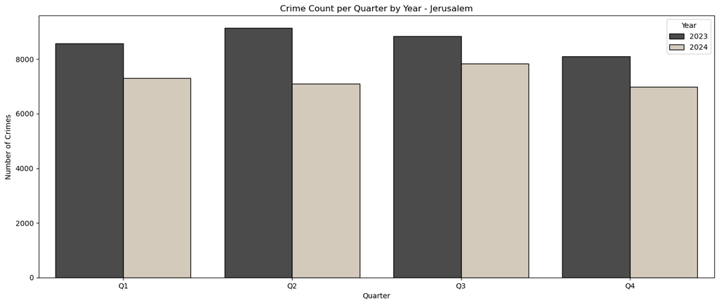

```python
jerusalem_df = df_Jerusalem[(df_Jerusalem["Yeshuv"] == "Jerusalem")]

all_cities_df = df_Jerusalem[(df_Jerusalem["Yeshuv"] != "Jerusalem")]


grouped = jerusalem_df.groupby(["Quarter", "Year"]).size().reset_index(name="Count")

quarter_order = ['Q1', 'Q2', 'Q3', 'Q4']
grouped['Quarter'] = pd.Categorical(grouped['Quarter'], categories=quarter_order, ordered=True)

grouped = grouped.sort_values(by=["Year", "Quarter"])

plt.figure(figsize=(14, 6))
sns.barplot(data=grouped, x="Quarter", y="Count", hue="Year",palette=custom_palette,edgecolor='black')

plt.title("Crime Count per Quarter by Year - Jerusalem")
plt.xlabel("Quarter")
plt.ylabel("Number of Crimes")
plt.tight_layout()
plt.show()
```

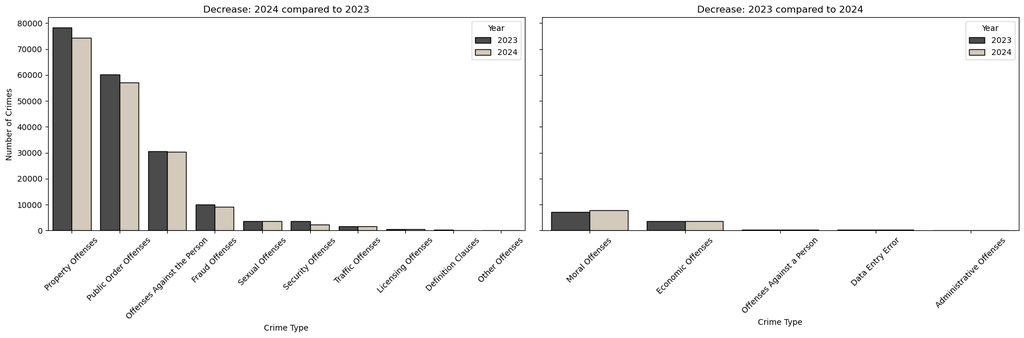

```python
import matplotlib.pyplot as plt
import seaborn as sns
import pandas as pd
import numpy as np

crime_counts = df_Jerusalem[df_Jerusalem["Year"].isin([2023, 2024])].groupby(["StatisticGroup", "Year"]).size().reset_index(name="Count")
pivot_df = crime_counts.pivot(index="StatisticGroup", columns="Year", values="Count").fillna(0)
pivot_df["Change"] = pivot_df[2024] - pivot_df[2023]
declined_crimes = pivot_df[pivot_df["Change"] < 0].reset_index()
plot_df = pd.melt(
    declined_crimes,
    id_vars=["StatisticGroup"],
    value_vars=[2023, 2024],
    var_name="Year",
    value_name="Count"

)

pivot_df_2024 = crime_counts.pivot(index="StatisticGroup", columns="Year", values="Count").fillna(0)
pivot_df_2024["Change"] = pivot_df_2024[2023] - pivot_df_2024[2024]
declined_crimes_2024 = pivot_df_2024[pivot_df_2024["Change"] < 0].reset_index()
plot_df_2024 = pd.melt(
    declined_crimes_2024,
    id_vars=["StatisticGroup"],
    value_vars=[2023, 2024],
    var_name="Year",
    value_name="Count"

)

fig, axes = plt.subplots(1, 2, figsize=(18, 6), sharey=True)
order1 = declined_crimes.sort_values(by=2024, ascending=False)["StatisticGroup"]
order2 = declined_crimes_2024.sort_values(by=2023, ascending=False)["StatisticGroup"]
sns.barplot(
    data=plot_df,
    x="StatisticGroup",
    y="Count",
    hue="Year",
    palette=custom_palette,
    edgecolor='black',
    ax=axes[0],
    order=order1
)
axes[0].set_title("Decrease: 2024 compared to 2023")
axes[0].set_xlabel("Crime Type")
axes[0].set_ylabel("Number of Crimes")
axes[0].tick_params(axis='x', rotation=45)
axes[0].legend(title="Year")

# גרף שני
sns.barplot(
    data=plot_df_2024,
    x="StatisticGroup",
    y="Count",
    hue="Year",
    palette=custom_palette,
    edgecolor='black',
    ax=axes[1],
    order=order2
)
axes[1].set_title("Decrease: 2023 compared to 2024")
axes[1].set_xlabel("Crime Type")
axes[1].set_ylabel("")
axes[1].tick_params(axis='x', rotation=45)
axes[1].legend(title="Year")

max_count = max(plot_df["Count"].max(), plot_df_2024["Count"].max())
axes[0].set_yticks(np.arange(0, max_count + 10000, 10000))

plt.tight_layout()
plt.show()
```

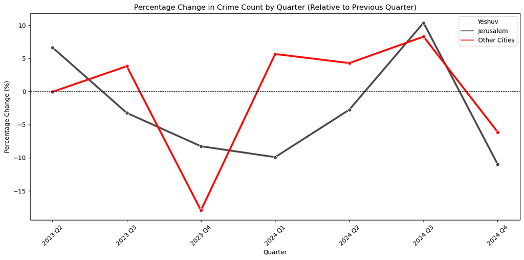

```python
df_Jerusalem = pd.read_csv("top20_ 23-24_.csv")
custom_palette = ["#4B4B4B", "red"]

jerusalem_df = df_Jerusalem[df_Jerusalem["Yeshuv"] == "Jerusalem"].copy()
other_cities_df = df_Jerusalem[df_Jerusalem["Yeshuv"] != "Jerusalem"].copy()

jerusalem_df["Time"] = jerusalem_df["Year"].astype(str) + " " + jerusalem_df["Quarter"]
other_cities_df["Time"] = other_cities_df["Year"].astype(str) + " " + other_cities_df["Quarter"]

quarter_order = ['Q1', 'Q2', 'Q3', 'Q4']
year_order = sorted(df_Jerusalem["Year"].unique()) # שימוש ב-df_Jerusalem שכבר הוגדר
time_order = [f"{year} {q}" for year in year_order for q in quarter_order]

jerusalem_df["Time"] = pd.Categorical(jerusalem_df["Time"], categories=time_order, ordered=True)
other_cities_df["Time"] = pd.Categorical(other_cities_df["Time"], categories=time_order, ordered=True)

grouped_jerusalem = jerusalem_df.groupby("Time", observed=False).size().reset_index(name="Count")
grouped_jerusalem["Yeshuv"] = "Jerusalem"

grouped_other = other_cities_df.groupby("Time", observed=False).size().reset_index(name="Count")
grouped_other["Yeshuv"] = "Other Cities"

combined = pd.concat([grouped_jerusalem, grouped_other])

combined = combined.groupby(["Yeshuv", "Time"],observed=False)["Count"].sum().reset_index()

combined = combined.sort_values(by=["Yeshuv", "Time"])

def calculate_percentage_change(series):
    previous = series.shift(1)
    change = (series - previous) / previous * 100
    return change

combined["Percentage_Change"] = combined.groupby("Yeshuv")["Count"].transform(calculate_percentage_change)

plt.figure(figsize=(12, 6))
sns.lineplot(data=combined, x="Time", y="Percentage_Change", hue="Yeshuv", marker="o", linewidth=3, palette=custom_palette)

plt.title("Percentage Change in Crime Count by Quarter (Relative to Previous Quarter)")
plt.xlabel("Quarter")
plt.ylabel("Percentage Change (%)")
plt.xticks(rotation=45)
plt.axhline(0, color='black', linestyle='--', linewidth=0.7) # הוספת קו ב-0%
plt.tight_layout()
plt.show()
```

**לסיכום**

1. היינו סקרניות לבחון את היקף מקרי הפשיעה בעיר מעורבת כמו **ירושלים**, דווקא בתקופה מורכבת מבחינה ביטחונית במדינה, בשנים **2023–2024**.
2. ההנחה הראשונית שלנו הייתה שנראה **עלייה** בכמות מקרי הפשיעה בירושלים, לאור היותה עיר גדולה, מעורבת ורב-תרבותית – מעין מיקרוקוסמוס של החברה הישראלית.
3. להפתעתנו, מצאנו כי **ברבעון האחרון של שנת 2023** חלה בירושלים **ירידה ניכרת** במספר מקרי הפשיעה – מגמה הפוכה ממה שציפינו לראות.
4. עוד גילינו כי **מגמת הירידה נמשכת גם ברבעון הראשון של שנת 2024**.
5. מעניין לציין כי בתקופות מסוימות, המגמות בירושלים **מנוגדות לאלו שנצפו ב-19 הערים הגדולות בישראל**, או שהפערים באחוזי השינוי בין ירושלים לשאר הערים **בולטים** – נתון מפתיע שסתר את ההשערות הראשוניות שלנו.

**הקשר בין מצב סוציו - אקונומי לנתוני פשיעה**

תחילה התמקדנו בהשוואה בין היקף הפשיעה בצפון תל אביב לבין דרום העיר, מתוך רצון להבין האם קיימים פערים משמעותיים בכמות העבירות בין אזורים בעלי מאפיינים חברתיים-כלכליים שונים בתוך אותה עיר.

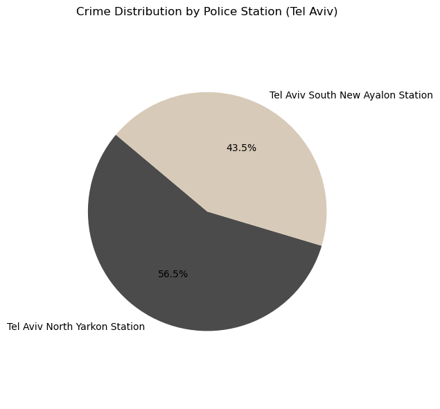

```python
df = pd.read_pickle("https://github.com/hadasl1/Crimes_in_Israel/raw/main/pickled_df_update%20(3)%20(1)")
custom_palette = ["#4B4B4B",
                  "#D8CAB8"]


tel_aviv = df[
    ((df["PoliceStation"] == "Tel Aviv South New Ayalon Station") |
    (df["PoliceStation"] == "Tel Aviv North Yarkon Station"))
]

count_by_station = tel_aviv.groupby('PoliceStation').size().reset_index(name='Station count')

labels = count_by_station['PoliceStation']
sizes = count_by_station['Station count']

plt.figure(figsize=(6, 6))
plt.pie(sizes, labels=labels, autopct='%1.1f%%', startangle=140,colors=custom_palette)
plt.title('Crime Distribution by Police Station (Tel Aviv)')
plt.axis('equal')
plt.tight_layout()
plt.show()
```

לאחר שהתברר כי אכן יש הבדלים בין כמות הפשיעה, רצינו לבדוק מה מאפיין את הפשיעה בצפון תל אביב

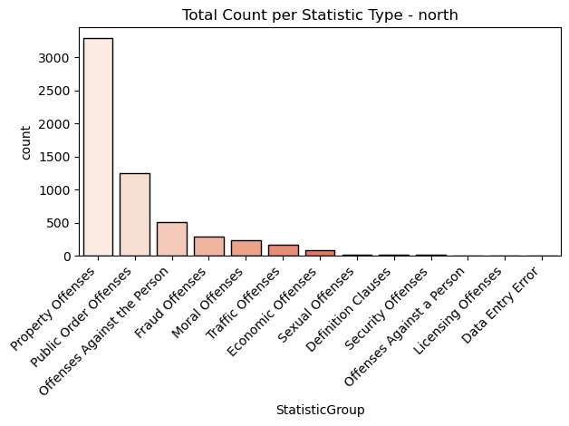

```python
north_all = df[df["PoliceStation"] == "Tel Aviv North Yarkon Station"].copy()
north_all['StationLabel'] = 'Tel Aviv North Yarkon'

south_all = df[df["PoliceStation"] == "Tel Aviv South New Ayalon Station"].copy()
south_all['StationLabel'] = 'Tel Aviv South Ayalon'


sum_crimes = north_all["StatisticGroup"].value_counts().reset_index()
top4 = sum_crimes.head(13)
sns.barplot(data=top4, y='count', x='StatisticGroup',
            dodge=False, errorbar=None, palette="Reds",edgecolor='black')
plt.xticks(rotation=45, ha='right')
plt.title("Total Count per Statistic Type - north")
plt.tight_layout()
plt.show()
```

כעת התברר כי סוג הפשיעה המוביל בצפון תל אביב הוא עבירות רכוש. ממצא זה מתיישב עם העובדה שאיזור צפון העיר מתאפיין ברמה סוצי-אקונומית גבוהה, ולכן ייתכן כי איזור זה מהווה יעד מועדף לפשעי רכוש

```python
property_offenses=tel_aviv[tel_aviv["StatisticGroup"]=="Property Offenses"]
lst_property_offenses=property_offenses["StatisticType"].unique()
data_property_offenses=pd.DataFrame({
    "Property Offenses":lst_property_offenses
})
data_property_offenses
```

|  | Property Offenses |
| --- | --- |
| 0 | Unauthorized Use of Vehicle |
| 1 | Malicious Property Damage |
| 2 | Other Thefts |
| 3 | Theft by Employees and Agents |
| 4 | Burglary into Residence |
| 5 | Bicycle Theft |
| 6 | Theft from Vehicle |
| 7 | Burglary into Businesses and Institutions |
| 8 | Theft of Vehicle Parts |
| 9 | Possession of Stolen Property |
| 10 | Pickpocketing |
| 11 | Arson |
| 12 | Aggravated Robbery |
| 13 | Possession of Burglary Tools |
| 14 | Cyber Offenses |
| 15 | Assault for Theft |
| 16 | Property Offenses |
| 17 | Extortion |
| 18 | Robbery |
| 19 | Purse Snatching |
| 20 | Theft by Public Employee |
| 21 | Trade and Possession of Stolen Vehicle Parts |

רצינו להציג את סוגי הפשעים בהם הדרום עולה על הצפון

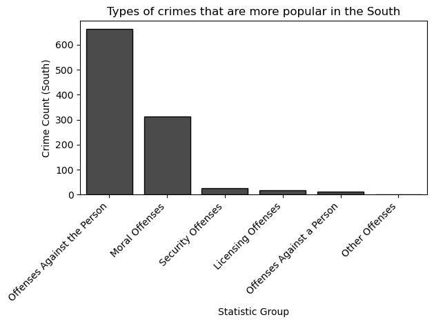

```python
custom_palette1 = ["#4B4B4B"]
count_by_type = tel_aviv.groupby(['PoliceStation', 'StatisticGroup']).size().reset_index(name='CrimeCount')

pivot_df = count_by_type.pivot(index='StatisticGroup', columns='PoliceStation', values='CrimeCount').fillna(0)

south_more_than_north = pivot_df[
    pivot_df['Tel Aviv South New Ayalon Station'] > pivot_df['Tel Aviv North Yarkon Station']
]

south_more_than_north = south_more_than_north.reset_index()
south_more_than_north = south_more_than_north.sort_values(by='Tel Aviv South New Ayalon Station', ascending=False).reset_index()

sns.barplot(
    data=south_more_than_north,
    x='StatisticGroup',
    y='Tel Aviv South New Ayalon Station',
    color="#4B4B4B",
    edgecolor='black'

)

plt.xticks(rotation=45, ha='right')
plt.title("Types of crimes that are more popular in the South")
plt.ylabel("Crime Count (South)")
plt.xlabel("Statistic Group")
plt.tight_layout()
plt.show()
```

```python
south_all = tel_aviv[tel_aviv["PoliceStation"] == "Tel Aviv South New Ayalon Station"].copy()
sum_crimes1 = south_all[south_all["StatisticGroup"]=="Moral Offenses"]
sum_crimes1["StatisticType"].value_counts()
```

```
StatisticType
Drug Trafficking, Import and Export                   130
Possession of Drugs for Non-Personal Use              129
Use of Dangerous Drugs                                 39
Publication of Obscene Material                         9
Cultivation, Production and Manufacturing of Drugs      3
Moral Offenses                                          1
Soliciting for Prostitution                             1
Name: count, dtype: int64
```

החלטנו שיהיה מעניין להסתכל על עבירות מסוג "moral offences" (שכוללות בתוכן גם עבירות סם) מהסיבה שאלה מתקשרות לנו כעבירות שמאפיינות מצב סוציו- אקונומי נמוך ולבחון את התפלגות סוגי העבירות מהקבוצה בצפון למול הדרום

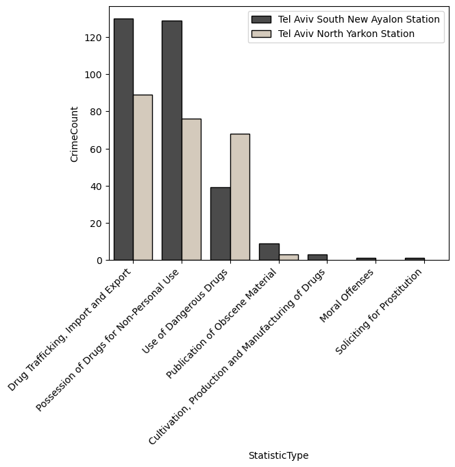

```python
custom_palette = ["#4B4B4B",
                  "#D8CAB8"]
tel_aviv_moral = tel_aviv[((tel_aviv["StatisticGroup"] == "Moral Offenses"))]
count_moral_by_sub_type = tel_aviv_moral.groupby(['PoliceStation', 'StatisticType']).size().reset_index(name='CrimeCount')
count_moral_by_sub_type = count_moral_by_sub_type.sort_values(by='CrimeCount', ascending=False)
sns.barplot(data=count_moral_by_sub_type, x='StatisticType', y='CrimeCount', hue='PoliceStation',  palette=custom_palette,edgecolor='black')
plt.legend(loc='upper right')
plt.xticks(rotation=45, ha='right')
plt.show()
```

הופתענו לגלות כי על אף הפער המשמעותי בסוג הפשיעה מהקטגוריה ״moral offences", החלוקה היא יחסית ברורה: בכל מה שקשור לאחזקה, ייבוא, ייצוא, וייצור של סמים - הדרום מוביל, אך בכל מה שקשור לצריכה - הצפון עולה על הדרום.

**לסיכום**

1. תחילה נציין כי המטרה הראשונית הייתה להבין האם קיימים הבדלים – ואם כן, אילו – בין היקף וסוגי הפשיעה בצפון תל אביב לבין דרום העיר.
2. ציפינו בתחילה לגלות שיעור גבוה יותר של מקרי פשיעה בדרום תל אביב, אך הופתענו לגלות כי **הנחת המוצא שלנו הייתה שגויה**.
3. מנגד, ראינו כי **פשעי רכוש** בצפון תל אביב נפוצים במיוחד – ממצא שדייק את ההבנה שלנו באשר למאפייני האזור.
4. בהמשך בחרנו להתמקד ב**עבירות סמים**, בהיותן עבירות שחוצות מגזרים ומעמדות, וניסינו להבין כיצד הן מתפלגות גיאוגרפית בעיר. בנוסף, העלינו השערה שעבירות סמים עשויות להיות קשורות לרקע סוציו-אקונומי נמוך.
5. התובנה המרכזית שהגענו אליה הייתה **מפתיעה יחסית**:
   - **עבירות צריכת סם** נפוצות יותר בצפון תל אביב.
   - לעומת זאת, **בדרום העיר נפוצות יותר עבירות "מעטפת"** הקשורות לצריכת סמים (למשל סחר, החזקה, שימוש באזורים ציבוריים).

**איך חופשת הקיץ משפיעה על הפשיעה בישראל**

תחילה רצינו לבדוק האם קיימת עליה בפשיעה בישראל, בקרב 20 הערים הגדולות, במהלך חודשי הקיץ (הרבעון השלישי) לעומת יתר הרבעונים לאורך השנה

```python
vication_df = pd.read_pickle("https://raw.githubusercontent.com/hadasl1/Crimes_in_Israel/main/pickled_vication_df%20(2)%20(1)")
all_df = pd.read_pickle("https://github.com/hadasl1/Crimes_in_Israel/raw/main/pickled_df_update%20(3)%20(1)")

Population=[995073,479153,296187,264001,257388,238796,221768,215704,197673,
175612,165582,159836,152576,129442,108956,104731,102283,101440,86968,50215,57800]
City=["Jerusalem","Tel Aviv-Yafo","Haifa","Rishon LeZion","Petah Tikva","Netanya","Bnei Brak","Beersheba","Holon","Ramat Gan","Beit Shemesh",
"Ashkelon","Rehovot","Bat Yam","Herzliya","Hadera","Modiin-Maccabim-Reut","Kfar Saba","Lod","Tiberias","Eilat"]


City_Population= pd.DataFrame({
    "City": City,
    "Population": Population
})
```

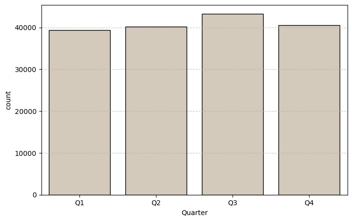

```python
plt.figure(figsize=(8, 5))
sns.countplot(data=all_df, x="Quarter",
              order=["Q1", "Q2", "Q3", "Q4"],
              color="#D8CAB8",edgecolor='black')
plt.xticks(rotation=0)
plt.grid(axis='y', linestyle='--', alpha=0.7)
plt.show()
```

העלינו את ההשערה כי ייתכן שהעלייה בפשיעה במהלך חודשי הקיץ נובעת בעיקר מהתרחשותה בעיירות נופש. לכן, בחנו את שיעור הפשיעה בעיירות הנופש באחוזים, והשווינו אותו לשיעור הפשיעה ביתר הערים הגדולות בישראל. בחרנו להתמקד בארבעת ערי הנופש הפופולריות בישראל - אילת, טבריה, ירושלים ותל אביב

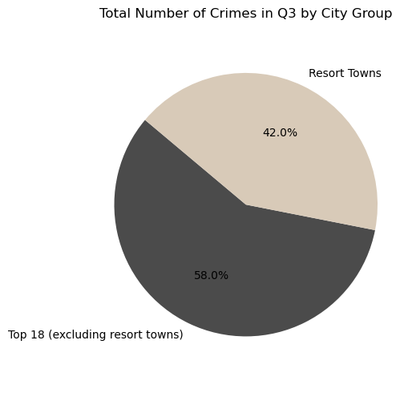

```python
custom_palette = ["#4B4B4B",
                  "#D8CAB8"]

cities_to_remove = ["Tel Aviv-Yafo", "Jerusalem"]
filter_new_q3 = all_df[(all_df["Quarter"] == "Q3") & (~all_df["Yeshuv"].isin(cities_to_remove))]
strike_vication_q3 = vication_df[vication_df["Quarter"] == "Q3"]

crime_counts = pd.DataFrame({
    "Group": ["Top 18 (excluding resort towns)", "Resort Towns"],
    "Total Crimes": [len(filter_new_q3), len(strike_vication_q3)]
})

plt.figure(figsize=(5, 5))
plt.pie(
    crime_counts["Total Crimes"],
    labels=crime_counts["Group"],
    autopct='%1.1f%%',
    startangle=140,
    colors=custom_palette,
)
plt.title("Total Number of Crimes in Q3 by City Group")
plt.axis('equal')
plt.tight_layout()
plt.show()
```

עקב ההנחה שקיים פער בין היקפי האוכלוסייה של קבוצות ההשוואה, רצינו להשוות בין ההיקפים הללו כדי לבצע נרמול של הנתונים בהמשך. מתוך ההבנה שכך נוכל להציג מסקנונת שמבוססות על ניתוח פרופורציונלי.

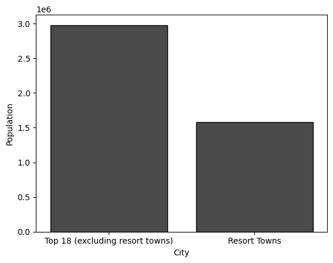

```python
Top_18=["Haifa","Rishon LeZion","Petah Tikva","Netanya","Bnei Brak","Beersheba","Holon","Ramat Gan","Beit Shemesh",
"Ashkelon","Rehovot","Bat Yam","Herzliya","Hadera","Modiin-Maccabim-Reut","Kfar Saba","Lod",]

resort_towns_list=["Jerusalem","Tel Aviv-Yafo","Tiberias","Eilat"]
city=["Top 18 (excluding resort towns)","Resort Towns"]
top_18_excluding_resort_towns = City_Population[City_Population["City"].isin(Top_18)]
resort_towns=City_Population[City_Population["City"].isin(resort_towns_list)]

City_Population_filter= pd.DataFrame({
    "City": city,
    "Population": [top_18_excluding_resort_towns["Population"].sum(),resort_towns["Population"].sum()]})
sns.barplot(City_Population_filter, x="City",y="Population",color="#4B4B4B",
    edgecolor='black')
```

נרמלנו את הנתונים כך שנוכל לבחון את כמות הפשיעה ביחס לגודל האוכלוסייה – כלומר, מספר מקרי הפשיעה לכל 10,000 תושבים – בכל אחד מהאזורים: עיירות הנופש מול יתר הערים.

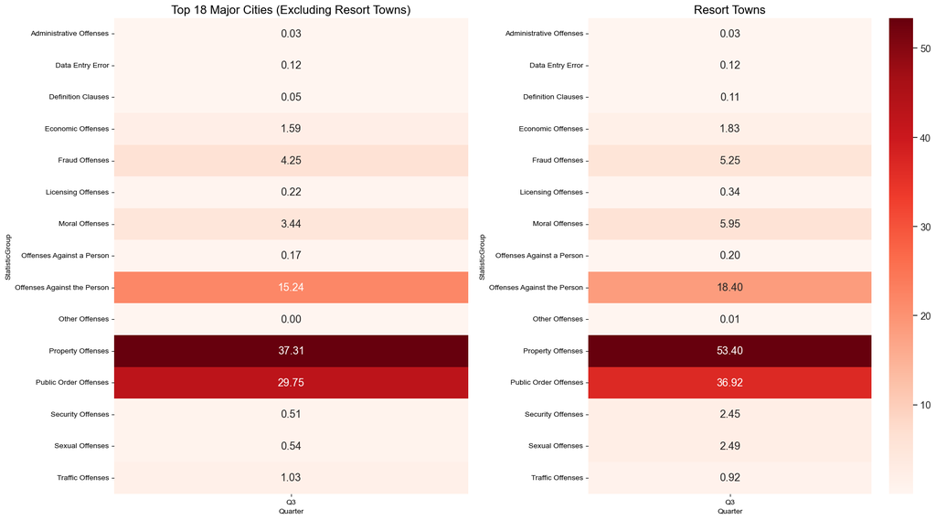

```python
palettes1 = ['Reds', 'OrRd', 'PuRd', 'coolwarm', 'RdGy', 'RdBu']
cities_to_remove=["Tel Aviv-Yafo",'Jerusalem']
filter_new_q3 = all_df[(all_df["Quarter"] == "Q3")]
filter_new_q3= filter_new_q3[~filter_new_q3["Yeshuv"].isin(cities_to_remove)]
strike_vication_q3=vication_df[vication_df["Quarter"] == "Q3"]

pivot = filter_new_q3.pivot_table(index="StatisticGroup", columns="Quarter", aggfunc="size", fill_value=0)
pivot1 = strike_vication_q3.pivot_table(index="StatisticGroup", columns="Quarter", aggfunc="size", fill_value=0)

pivot_normalized = (pivot / top_18_excluding_resort_towns["Population"].sum()) * 10000
pivot1_normalized = (pivot1 / resort_towns["Population"].sum()) * 10000

fig, axes = plt.subplots(figsize=(18, 10), ncols=2)
sns.set(font_scale=1.2)

sns.heatmap(pivot_normalized, cmap="Reds", annot=True, fmt=".2f", ax=axes[0], cbar=False)
axes[0].set_title("Top 18 Major Cities (Excluding Resort Towns)", fontsize=16)
axes[0].tick_params(axis='y', labelrotation=0)

sns.heatmap(pivot1_normalized, cmap="Reds", annot=True, fmt=".2f", ax=axes[1])
axes[1].set_title("Resort Towns", fontsize=16)
axes[1].tick_params(axis='y', labelrotation=0)

plt.tight_layout()
plt.show()
```

**לסיכום**

1. התחלנו לעסוק בתובנה הזו בגישה יחסית סקפטית. הנחנו שאולי נראה הבדלים בין הרבעון השלישי לבין שאר הרבעונים, אך לא היינו בטוחות שהם יהיו משמעותיים מספיק כדי להתקדם מכאן.
2. לאחר שזיהינו שקיים הבדל מסוים, החלטנו לשנות מעט כיוון ולבחון מה קורה בעיירות הנופש הישראליות במהלך חודשי הקיץ. זאת מתוך ההנחה שרבים מאזרחי המדינה בוחרים לבלות בהן ברבעון השלישי – על אחת כמה וכמה בשנת מלחמה, שבה תיירות החוץ הייתה פחות נגישה בעקבות השבתת טיסות של חברות תעופה זרות.
3. הופתענו לגלות כי לאחר נרמול הנתונים, קיימים פערים משמעותיים מאוד בכמות הפשיעה בעיירות הנופש במהלך הרבעון השלישי, לעומת יתר הערים הגדולות בישראל. זהו ממצא מטריד, שעורר אצלנו מחשבה ותהיות לגבי אופייה המוסרי של התיירות הישראלית המקומית.